# Truck model

Lachlan Fox

20/12/2021

# Modelling the Australian heavy vehicle fleet

This R-markdown document sets out the assumptions and details of the Grattan model used to estimate the CO2 and pollutant emissions of the Australian heavy vehicle fleet.

This model is used to analyse potential policy options for the Australian heavy vehicle fleet – including programs targeted at removing old vehicles from the fleet, policies aimed to reduce fuel consumption of new vehicles, and policies to spur uptake of zero emissions heavy vehicles.

Overall assumptions underpinning the model are discussed first, followed by a discussion of individual policy options analysed.

# The fleet turnover model

A fleet turnover model is a model that predicts the composition of a vehicle fleet. In this case, we are modeling the Australian heavy vehicle fleet (including vehicles above 3.5 tonnes). We estimate the composition and activity of the fleet over time based on sales estimates, estimated vehicle scrappage rates, projected economic activity and estimates of VKTs (vehicle kilometres travelled).

## Vehicle attrition rates

Vehicle attrition rates were estimated on an age basis using ABS tablebuilder data from the motor vehicle census (years 2013-2021). The code for this analysis is included in `R/model-inputs/01-vehicle-attrition.R`.

Heavy vehicles were initially aggregated into five categories:

- Buses (> 9 seats)
- Light Rigid trucks (3.5-4.5t)
- Heavy Rigid Trucks (> 4.5t)
- Prime Movers
- Non-freight carrying trucks (including Fire Appliances, Trucks with Machinery Mounted, Other Non Freight Carrying Trucks, Tow Trucks)

Attrition rates were calculated by comparing vehicles between subsequent motor vehicle censuses. By comparing, for example, the 2014 census to the 2013 census, we compared how many vehicle on register for each age group in the 2013 census survived to the 2014 census (where they would show up as 2013 age + 1).

The proportion of vehicle in each category surviving was calculated between the censuses from 2013-2020, and an average rate was calculated fro each age group.

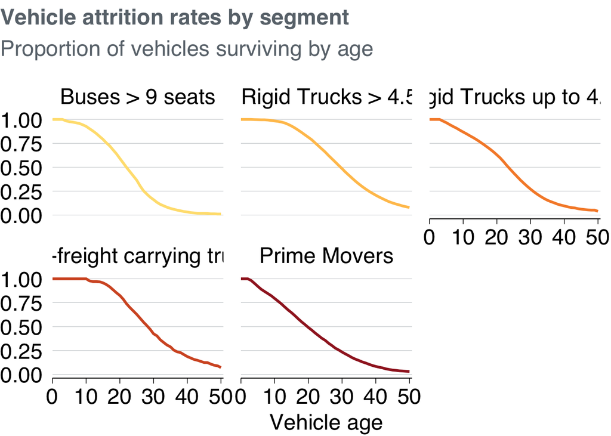

## Vehicle sales

Although the ABS motor vehicle census provides data on registered vehicles from 2013 onward, there is limited data available prior to 2013. However, to build a model of the heavy vehicle fleet, sales before this year are a key variable.

To estimate sales in each heavy vehicle category prior to 2013, vehicle attrition rates (as estimated above) were used to back-calculate vehicle sales. For example, at age 20, vehicle attrition rates may for example estimate that 20% of vehicles in a given category are still on register. Using the most recent MVUS (2021), by comparing how many vehicles sold in 2001 (20 years ago) are on register, an estimate of how many vehicles were initially sold can be calculated. If 5000 sold in 2001 are still on register in 2021, using the 20% surviving figure it can be estimated that 5000 * (1/0.2) = 25,000 new vehicles were sold in 2001 (these examples are illustrtive only).

To estimate future sales, it was assumed that sales will grow in line with population growth. Data on population growth was taken from the 2021 intergenerational report. Because historical sales are very volatile over time, the baseline figure for future forecasts was calculated as a 10 year average of past sales.

Past and forecast sales estimates using this method are included below.

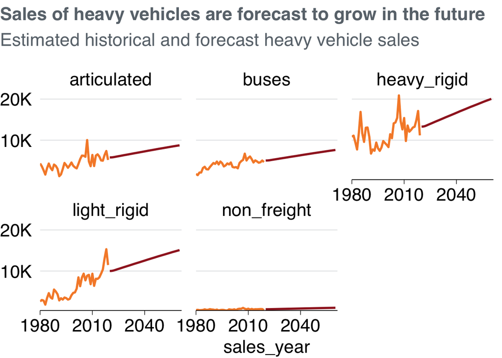

## Vehicle kilometres traveled (VKTs) and estimated activity

### VKTs

There is limited data available to estimate VKT’s for Australian heavy vehicles. While the ABS motor vehicle use survey includes some high level results of the kilometres travelled by different vehicles types, and and vehicles of different ages, these categories are broad - for example, vehicle kilometres based on age are grouped into three categories only; < 5 years old, 5-15 years old, and >15 years old.

Estimating the total activity of trucks requires estimates of VKTs for trucks of all ages, not just in broad categories. This is particularly important given that the estimates from this model are intended to estimate vehicle pollution; which is dependent on how old a vehicle is (or more accurately, the technology in the vehicle, which has improved over time). As vehicles age, they tend to drive fewer kilometres per year – for example, a 15 year old truck is unlikely to cover the same average distance as a 5 year old vehicle. If estimates fail to capture this relationship between VKTs and age, the share of driving from older, more polluting vehicle is likely to be significantly overestimated.

Given the lack of available data on the relationship between VKTs and age in an Australian context, estimates from the US MOVES model were adapted to an Australian setting. Equations for truck types from the US MOVES model (https://citeseerx.ist.psu.edu/viewdoc/download?doi=10.1.1.360.3323&rep=rep1&type=pdf) were initially mapped to known data in Australia for articulated, rigid, and non-freight carrying trucks, providing trends for VKTs vs age.

For articulated trucks, given the MOVES data is a polynomial function that is only appropriate for trucks aged ~1-16 years, beyond 16 years it is assumed articulated truck VKTs follow a linear relationship, calibrated to provide consistent estimates with what is available from the ABS motor vehicle use census data.

Rigid trucks were similar adapted for an Australian setting, both in terms of the base km travelled, and the function itself. Minor dilations/translations were made to the MOVES function to provide similar estimates to the ABS MVUS.

Given there is a lack of MOVES data available for buses, they were assumed to follow a piecewise linear relationship. Buses were assumed to travel a constant distance for the first 10 years of operation, before declining linearly between ages of 10 and 30. They are assumed to cease operation at 30 years of operation (an assumption consistent with the attrition curves for buses).

All vehicle categories were also adjusted at age 0. Given that vehicles are likely to be sold throughout the year, and only in operation for part of it, the average VKT of a new (age 0) vehicle was assumed to be half of that otherwise estimated.

The resulting VKT curves are included below:

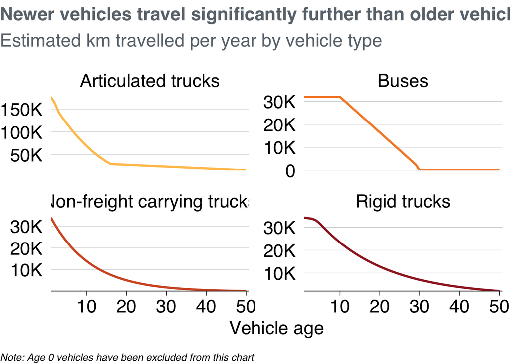

### Vehicle activity estimates

Although the above curves provide an estimate of how far a given vehicle might travel based on its age and vehicle type, actual road freight activity is also determined by prevailing economic conditions and demand. As a result, it’s appropriate to scale the overall activity (or total VKTs) of the fleet based on forecasts of economic activity.

This is separate from the growth in freight caused by population growth, which is factored into estimates of future vehicle sales and fleet growth.

Three scenarios are assumed for growth in fleet activity - a central estimate, lower, and upper bound. The central estimate assumes that future fleet activity grows at a rate of 35% of GDP, a trajectory that when combined with increased fleet growth in line with population growth estimates, predicts overall freight activity to increase approximately in line with BITRE estimates (2019 - https://www.bitre.gov.au/sites/default/files/documents/research_report_152-final.pdf). The lower bound assumed that fleet activity grows at 10% of GDP rates, and the upper bound scenario assumes that freight activity grows at 60% of the rate of forecast GDP growth (above the expected growth in line with population estimates).

Data for GDP forecast growth was taken from the 2021 intergenerational report.

Where vehicle activity estimates differed from historical estimates, activity is scaled in line with baseline results to provide consistency. The resulting estimated growth in VKTs over time is included below. Assuming no change in truck loads over time, this also corresponds to a forecast of growth in the total road freight task.

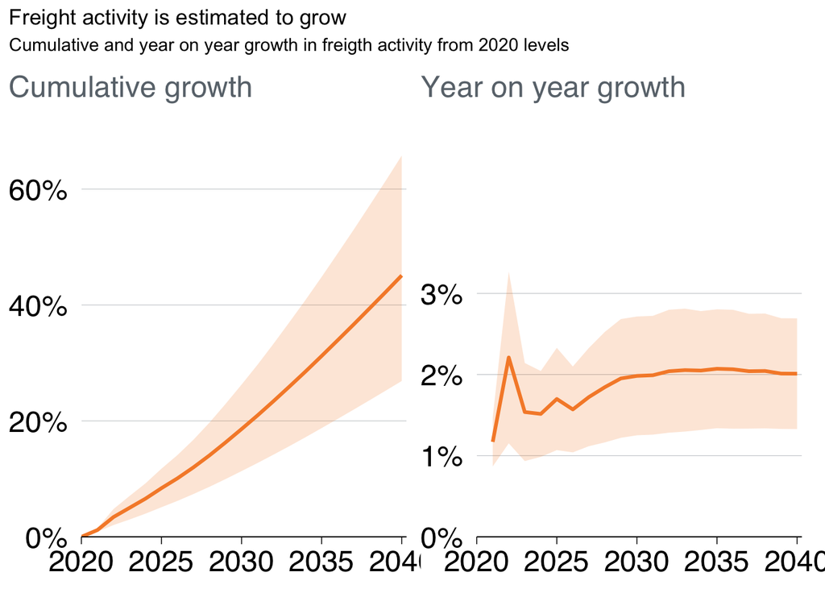

## Fuel consumption estimates

Fuel consumption in the road freight sector depends on many variables – for example the type of truck, engine/truck efficiency, payload and driving conditions.

Detailed data on each of these variables is both unavailable, and likely beyond the needs of this modelling. In practice, fuel consumption averages tend to fluctuate in relatively narrow bands for different truck types, and reasonable estimates can be made using average values and trends over time.

Fuel consumption estimates for the Grattan model were based on data from the ABS MVUS. For articulated trucks sold before 2020, trucks within each ABS age band (<5, 0-15, >15) are ascribed the average fuel consumption rate for each band. For all categories, it is assumed for vehicles sold from 2021 onwards, that there are year on year efficiency improvements of 0.5% to fuel consumption (following assumption made in the nationa GHG accounts methodology).

Similar assumptions are made for non-freight carrying trucks - however, given that there is no clear difference in fuel consumption for non-freight carrying trucks of different ages, a single constant value is assumed for vehicles sold before 2020. For rigid trucks, a constant fuel consumption rate is assumed for vehicles sold before 2000. From 2000 to 2020, vehicles are assumed to follow a linear relationship determined from the MVUS. A similar approach is taken for buses, with a constant value assumed for buses made before 2005; a linear improvement assumed for vehicles between 2005 and 2020, and a set 0.5% efficiency improvement for vehicles sold after 2020.

## Electric/Zero emission vehicle forecasts

Although the current heavy vehicle fleet has a negligible proportion of electric or zero emissions vehicles in operation, this is likely to change over time. The switch to heavy vehicles is unlikely to be fast, given zero emissions vehicle technology for heavy vehicles is in its infancy. However, as this modeling extends relatively far into the future, it needs to be considered to create a realistic estimate of the fleet.

To estimate Australian zero emissions heavy vehicle uptake, a lagged uptake of European forecasts was used for articulated, rigid and non-freight carrying trucks (McKinsey: https://www.mckinsey.com/industries/automotive-and-assembly/our-insights/whats-sparking-electric-vehicle-adoption-in-the-truck-industry). A lag of 5 years was assumed. Non-freight carrying trucks were assumed to follow the same trajectory as articulated trucks.

Buses were modeled separately, and assumed to meet 25% in 2030, 60% by 2035, and 100% by 2040. The rate of bus electrification is likely to be driven by state government decision making.

For the purposes of estimating emissions, it is assumed that all zero emission heavy vehicles are electric vehicles. The enrgy consumption is assumed in line with upper bound estimates from the ICCT (https://theicct.org/sites/default/files/publications/EU-logistics-electrification-fv-202011.pdf) for the 2020 base year. Between 2020 and 2030, it is assumed that energy consumption declines by 2.8% per year, in line with ICCT forecasts for Europe (https://theicct.org/wp-content/uploads/2021/11/tco-bets-europe-1-nov21.pdf). Energy consumption figures are estimates to remain steady beyond 2030.

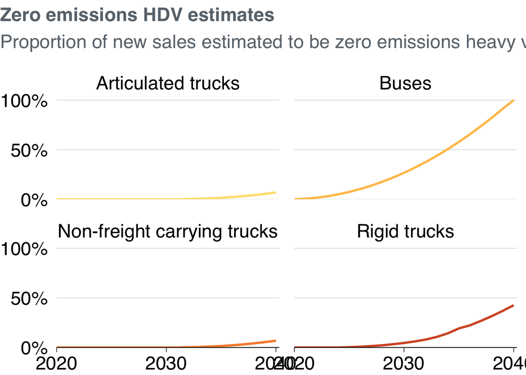

## Carbon emissions

For diesel vehicles, carbon emissions are estimated based on total fuel consumption estimates. A conversion ratio between fuel consumption and CO2 production is assumed in line with the NTC/Department of Climate Change 2009 (https://www.ntc.gov.au/sites/default/files/assets/files/Carbon%20dioxide%20emissions%20intensity%20for%20new%20Australian%20light%20vehicles%202020.pdf page 10).

For electric vehicles, carbon emissions are estimates based on estimated electricity use, and the carbon intensity of the electricity grid. It is assumed all vehicles are charged using energy from the electricity grid. Estimates for the carbon intensity of the grid between 2020 and 2040 follow the AEMO ‘step change’ scenario. Beyond 2040, it is assumed the grid linearly decarobnises to zero emissions in 2050, and stays at zero emissions beyond 2050.

## Pollutant emissions

Estimates for exhuast pollutant emissions from the heavy vehicle fleet are based on total fuel consumption, and emissions factors for various pollutants and vehicle types (reported as gram of pollutant per litre of fuel burned). Esimates of non-exhaust pollutants, such as brake and tyre wear, are estimates as a ‘per kilometre’ figure.

Pollutant emissions factors were provided by BITRE (pers comm), and subset by vehicle age, vehicle type, and fuel type.

It is assumed that 95% of exhuast PM10 (particulate matter smaller than 10um in aerodynamic diameter) particles are PM2.5 by mass (particulate matter smaller than 2.5um in aerdynamic diameter) and the remaining 5% fraction is PM2.5-10.

Values for tyre and brake wear values are assumed in line with the US EPA MOVES model (https://cfpub.epa.gov/si/si_public_file_download.cfm?p_download_id=525701 pages 16 and 24).

Secondary PM2.5 pollution from SOx and NOx emissions are estimated based on offset conversion factors. An offset factor of 1:100 is assumed for NOx, and 1:40 for SOx - meaning that for each gram of NOx formed, 0.01g of secondary PM2.5 is assumed to form, and for 1g of SOx emissions, 0.025 grams of PM2.5 is formed. This approach is consistent with US NACAA (National association of clean air agencies) methodology for estimating secondary pollutant emissions. The ratios assumed are ratios used for the west coast of the US (https://www.4cleanair.org/wp-content/uploads/2021/01/01072011-NACAAPM2.5ModelingWorkgroupReport-FINAL_3.pdf , page 18).

Particulate matter from road wear and re-entrained road dust is not included in this analysis.

## Pollutant health costs

The emission of pollutant emissions such as PM10 or NOx emissions has a harmful affect on health - particularly in densely populated, urban areas. The extent of the health cost caused by pollutants can be estimated by using `damage cost` figures; often expressed in as $ / tonne of pollutant emitted.

By multiplying the emissions through by damage costs, an estimate of total health costs under various policy scenarios can be forecast. We assume damage costs as provided by BITRE (pers comm). These estimates are devloped from impact pathway modeling conducted by Jacob Marsden Ass. (2016) as part of a review into fuel quality and vehicle emissions.

While highly uncertain, these costs are comparable with the range of other costs estimated in the literature (for example in the US: https://iopscience.iop.org/article/10.1088/1748-9326/ab1ab5/pdf)

Costs are dissagregated into rural and urban costs to account for the differences in population exposure, and are assumed to increase over time in line with population growth and demographic changes. Disagregation into rural and regional emissions is determined by assigning each vehicle with a proportion of driving in each conditions. This share is calculated from the ABS motor vehicle use survey (2018) for each vehicle type, and assumed to be constant with vehicle age and over time

# Business as usual scenarios

### Carbon emissions

Under the assumptions listed above, we estimates that CO2 emissions from freight will continue to grow out to 2030. Our estimates are slightly higher than Energia/DISER estimates which inform the 2021 national GHG accounts - however, the Energia estimates are within the confidence intervals predicted. Past GHG accounts estimates are also within the confidence intervals.

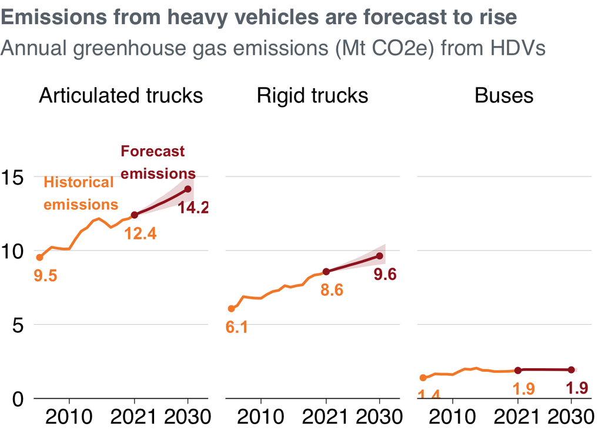

### Pollutant emissions

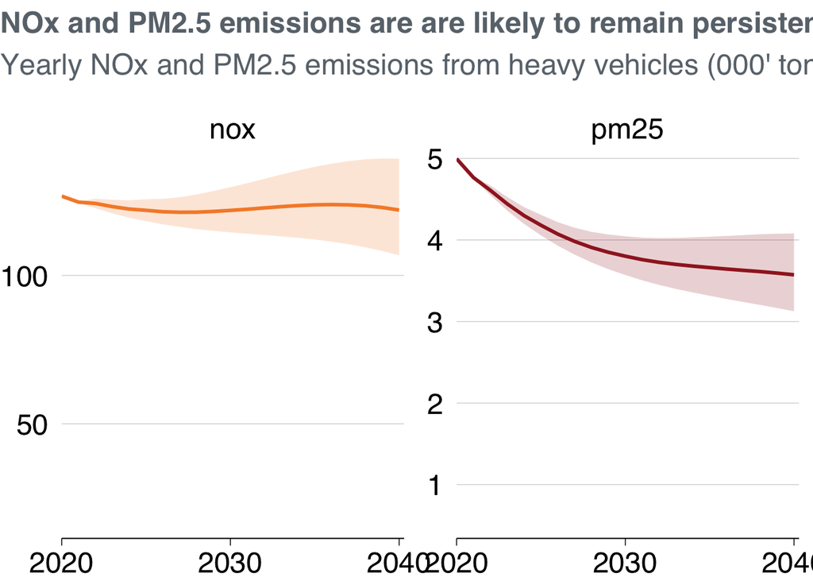

Under a business as usual scenario, the health costs attributable to pollution from heavy vehicles is also estimates to be conseridable, and growing (below).

# Pollutant health costs

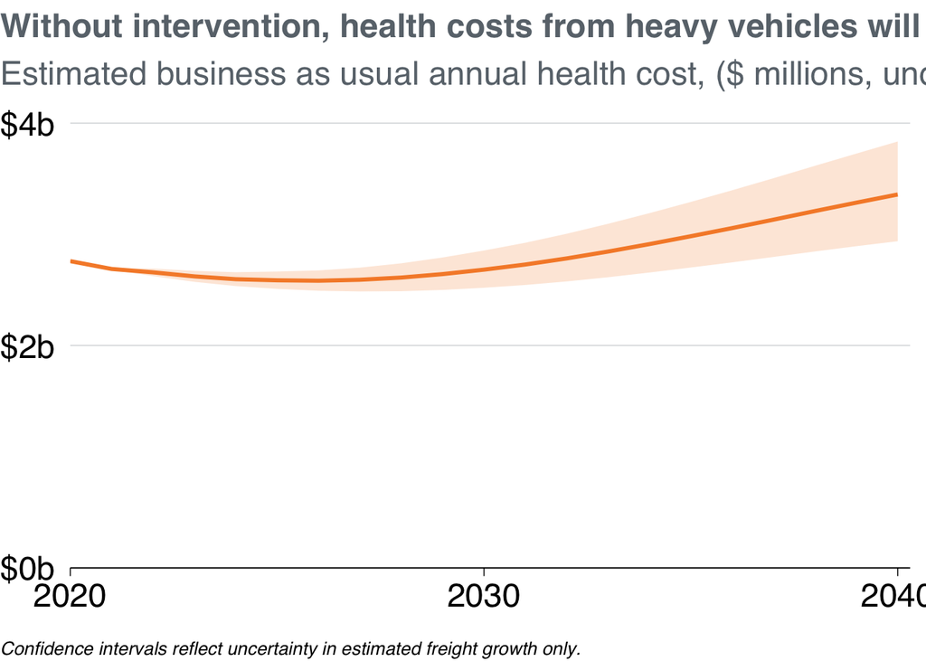

The fraction of cost attributable to each vehicle segment differs considerably. Rigid trucks are estimated to be responsible for the largest fraction of health costs, followed by articulated trucks.

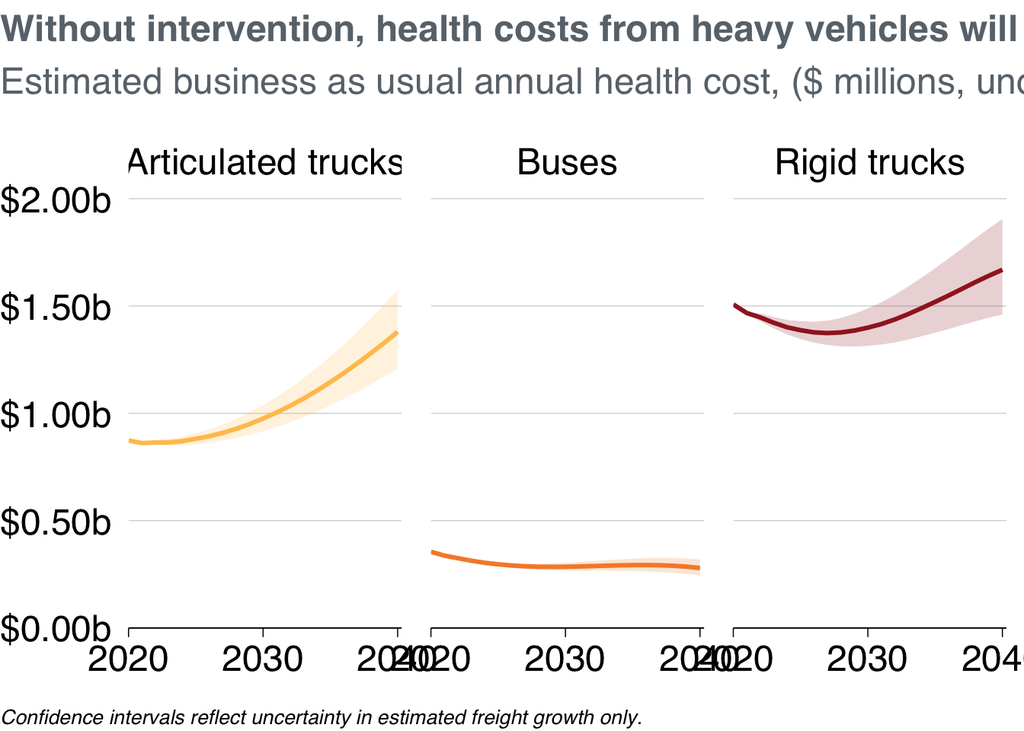

# Policy scenarios

The above two scenarios for carbon dioxide and pollutant emissions are business as usual scenarios - scenarios we consider likely to occur with no action taken. However, there are various policy levers that can be used to lower carbon and pollutant emissions.

The following section explores forecast carbon dioxide emissions, and for pollutant emissions, health costs, associated with various policy interventions.

# Policies to reduce pollution

### Euro VI pollutant standards

Euro VI pollutant standards for heavy vehicles are common globally and have been proposed many times for Australia. The following charts illustrate the estimated affect of Euro VI regulations on pollutant emissions from the heavy vehicle fleet.

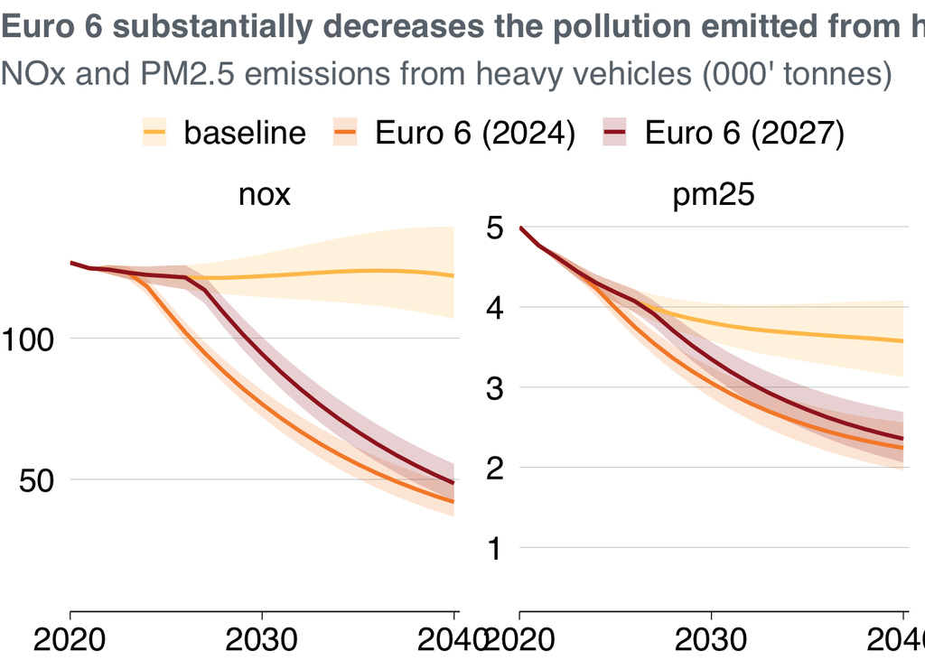

The resulting decline in pollutant emissions from heavy vehicles also translates to far lower long term health costs under a Euro 6 scenario compared to a business as usual case.

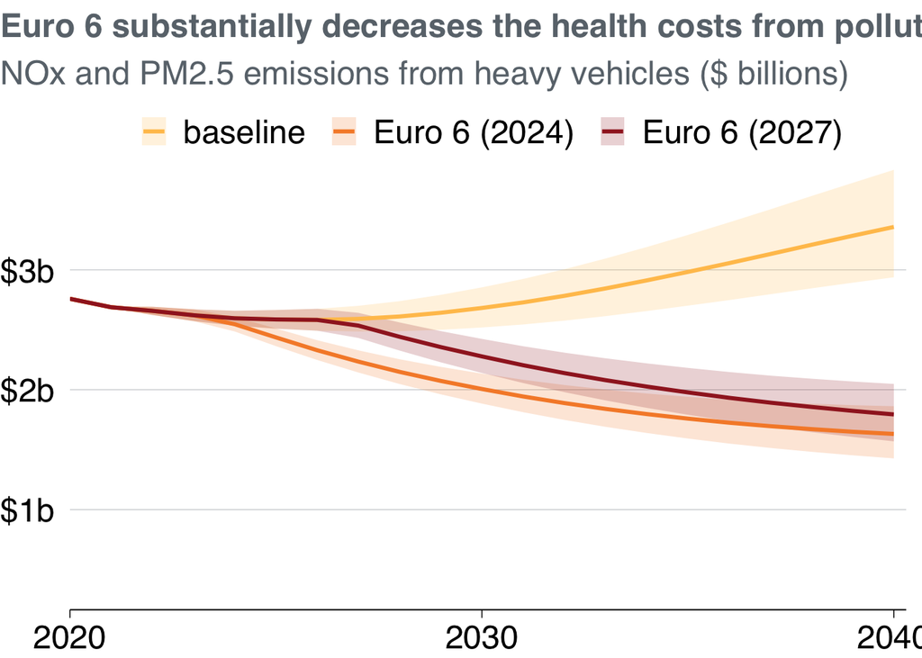

## Policies targetted at older vehicles

Although implementing Euro VI regulations is effective in reducing emissions from new vehicles, pollution from the heavy vehicle fleet is disproportionately produced by older vehicles, with worse pollutant reducing technology. Governments around the world have put in various programs aimed at reducing the average age of their heavy vehicle fleets, to reduce the burden of pollution caused by these odler vehicles.

The following chart breaks down the health costs over the age profile of the fleet for the year 2022. It demonstrates that while old vehicle are not particularly problematic for articulated trucks, older rigid trucks (15-20 years old) contribute significantly to overall health costs.

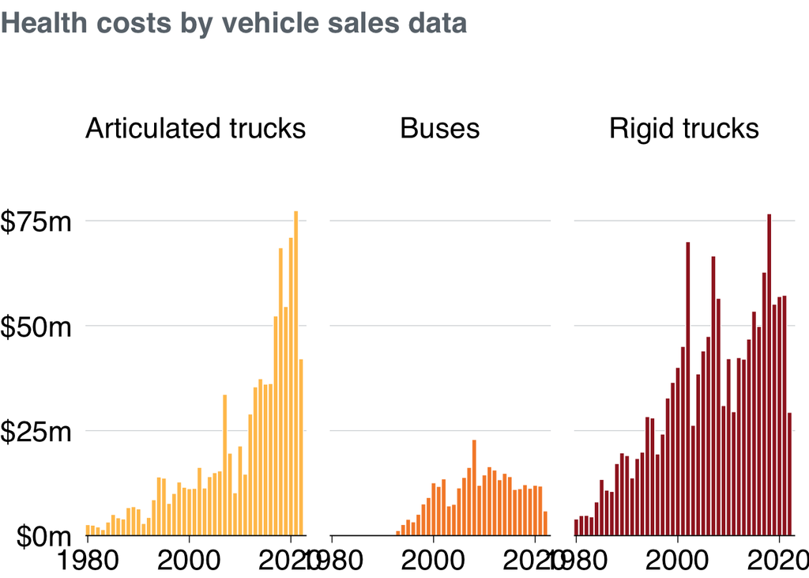

Although new vehicles do appear to cause the most health damage in total, the health costs caused by older vehicles is still significant – particularly given that there are far fewer older vehicles by number than new vehicles. This is particularly true for rigid trucks, where vehicles sold up to 20 years ago have considerable costs associated with them. Estimates of the health cost by vehicle age on a ‘per vehicle’ basis is included below, for the remaining life of the vehicle.

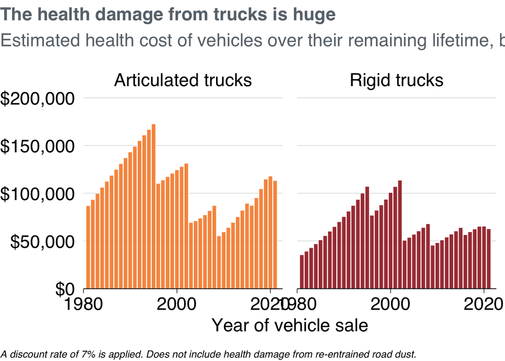

The above chart considers a lifetime health costs of a vehicles, depending on it’s sales date. This cost is the health cost that would be avoided if that vehicle was taken off the road, and not replaced in the fleet. The following chart below considers a similar scenario, but instead of being removed from the fleet altogether a vehicle is assumed to be ‘replaced’ with a Euro 3 vehicle (2003-era). This is equivalent to if the vehicle was retrofit to a Euro 3 standard.

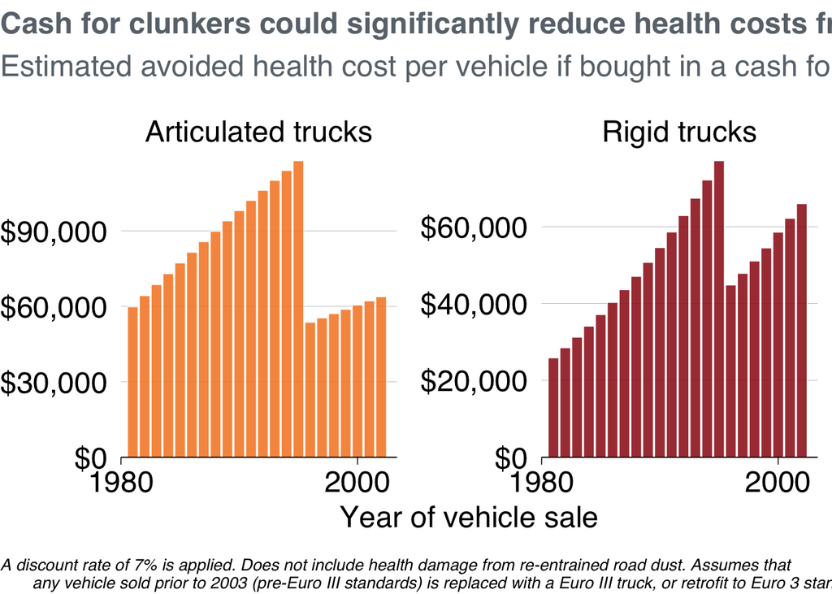

# Policies to reduce carbon emissions

Two key scenarios were considered to reduce carbon emissions. This includes a ‘technology target’ scenario, where new heavy vehicles are required to meet efficiency targets for engines and tyres, reducing their fuel consumption and carbon emissions. The second scenario is a zero emissions target scenario, where policies are implemented to accelerate the uptake of zero emissions trucks.

## Technology standards

Technology standards would ascribe targets heavy vehicle manufacturers must meet for new vehicle sales. In particular this is intended to be targeted at engines and tyres, as international evidence has suggested they are cost effective paths for reducing vehicle emissions. Engine standards would require manufacturers to meet target improvements to engine efficiency on average across the vehicles they sell. Tyre mandates would be imposed in a similar way – requiring either tyre manufacturers or vehicle manufacturers to sell tyres for eheavy vehicles which meet targeted rolling resistance improvements annually.

## Electric and zero emissions vehicle targets

Internationally, setting targets for the uptake of zero-emissions heavy duty vehicles (ZE-HDVs) is becoming more common. This is intended to spur uptake, given that zero emissions vehicles carry benefits in CO2 reduction, cost savings for operators, and reduced health costs through less pollution. We consider a scenario where binding sales targets are set to achieve 30% or Rigid truck sales to be zero emissions by 2030, and 100% by 2040, and 20]% of articulated truck sales to be zero emissions by 2030, and 70% by 2040.

The forecast carbon emissions of the two scenarios (zero emissions targets and technology standards) are included in the chart below.

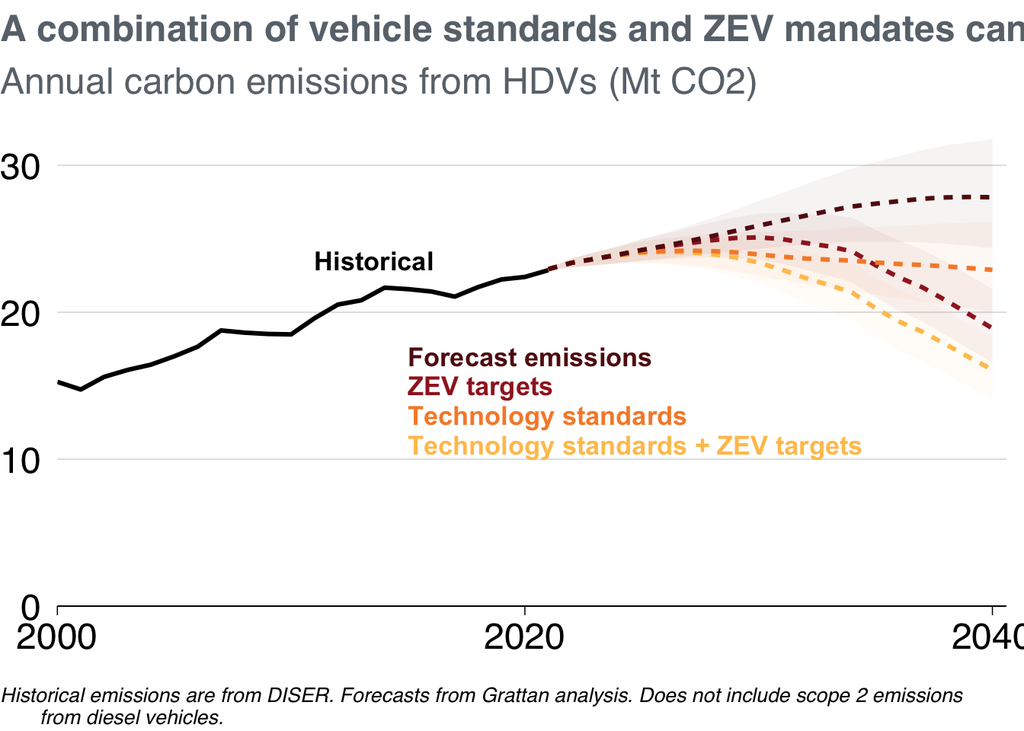

## Costing technology standards and zero emissions targets

## Technology standards

Technology standards would impose a mandated average improvement to fuel efficiency, for new vehicle sales. Standards to engine and tyre technology would be applied seperately, with different targets.

### Engine standards

International evidence suggests that 3% improvements per year form a baseline Euro 5 2022-era vehicle are achievable between 2024 and 2030. This would provide cumulative benefits of 18% reduction in fuel consumption and CO2 production by 2030

Australian engines are currently behind international comparisons. While Euro V engines for heavy vehicles are standard in Australia, internationally, Euro VI vehilces are mandated. Euro VI vehicle tend to have fuel consumption rate approximately 5-7% lower than Euro V vehicles.

International evidence also suggests substantial further improvements are available. From a Euro VI baseline engine, the ICCT estimate that 8% reductions in CO2 are available. With waste heat recovery, this is estimated to be 11-12%, and longer term imprvoements are estimated to be 15.8-18.1%. Combined with the benefit from switching from Euro V to Euro VI, this comfortably exceed 15-20% in total improvements. (EU study: https://theicct.org/wp-content/uploads/2021/06/EU-HDV-Tech-Potential_ICCT-white-paper_14072017_vF.pdf). There is also substantial evidence put forward by teh ICCT to demonstrate that such improvements are cost effective, with a payback period of under 5 years.

Evidence from the US is also promising. Between the 2018-2027 period, US engine regulations will mandate a combined engine efficiency improvement of 9-12% depending on vehicle type. This also starts from a baseline engine configuration that is likely to be more efficient than a Euro V era 2022 Australian vehicle (https://theicct.org/publication/u-s-efficiency-and-greenhouse-gas-emission-regulations-for-model-year-2018-2027-heavy-duty-vehicles-engines-and-trailers/).

Other, higher potential have also been put foward: (https://theicct.org/sites/default/files/publications/ICCT_position-brief_HDVenginetech-India_jun2015.pdf) indicates a 24% potential reduction.(https://theicct.org/publication/efficiency-technology-potential-for-heavy-duty-diesel-vehicles-in-the-united-states-through-2035/)

### Tyre standards

Evidence from the European Union suggests that improvements to tyre rolling resistance of about 2-4% per year are feasible over the 2020-2030 timeframe – corresponding to a CO2 reduction of about 7-10% by 2030. (https://theicct.org/sites/default/files/publications/EU-HDV-Tech-Potential_ICCT-white-paper_14072017_vF.pdf) Studies from the US have also estimated similar improvement are available (https://theicct.org/wp-content/uploads/2021/12/efficiency-tech-potential-hdvs-us-2035-nov21.pdf). Further, Australian trucks are currently limited in their ability to use low rolling resistance tyres, such as ultra-wide base next generation tyres. On an articulated truck, the truck industry council of Australia estimates these tyres could yeild an efficiency improvement of ~7% alone.

Each of these improvements has been found to have a pay back period of well under 5 years (and in many cases under 1-2 years).

Between 2024 and 2030, it is reasonable to expect that fuel efficiency improvements of 1.5% per year from a baseline 2022 vehicle are achievable – corresponding to an 11% reduction in fuel consumption by 2030.

## Zero emissions targets

To cost the zero emissions targets policy options, we conducted a cost benefit analysis of the target scenario against a baseline scenario. The key variables included are:

Costs * Upfront additional cost of zero emissions vehicles * Additional cost of charging infrastructure required for ZE-HDVs * Additional vehicles required (based on a time and weight penalty) for ZE-HDVs

Benefits * Avoided carbon emissions * Avoided health costs from pollution * Running cost savings from reduced fuel use * Maintenance cost savings, including reduced servicing/oil + lubricants, and adblue requirements

The evaluation period is from 2022 until 2040, with residual benefits between 2040 and 2060 included. Discount rates of 7% and 4% are applied.

Estimates of the costs and benefits are derived from the model as described in this document. Additional costs and benefits not described above and included in the following sections.

### Diesel and electricity prices

It is assumed that diesel and electricity prices remain constant over the evaluation period. Diesel is assumed at 1.33$/L for truck operators, and electricity at $0.15/kW. This is assumed in line with estimates from Australian Trucking Association (https://electricvehiclecouncil.com.au/reports/electric-trucks-keeping-shelves-stocked-in-a-net-zero-world/)

### Upfront vehicle costs

The upfront costs of zero emission and deisel vehicles is assumed in line with CSIO estimates between 2020 and 2050 (https://aemo.com.au/-/media/files/electricity/nem/planning_and_forecasting/inputs-assumptions-methodologies/2021/csiro-ev-forecast-report.pdf).

### Maintenance and ablue costs

Maintenance costs are assumed in line with ATAP estimates (https://www.atap.gov.au/parameter-values/road-transport/2-vehicle-operating-cost-voc-components) for Australian vehicles by type. In line with ICCT estimates (https://theicct.org/wp-content/uploads/2021/06/ICCT_EV_HDVs_Infrastructure_20190809.pdf), it is assumed that maintenance costs for electric vehicles are 30% lower than for diesel vehicles.

Oil and lubricant use costs are assumed in line with ICCT estimates for diesel vehicles (https://theicct.org/wp-content/uploads/2021/06/ICCT_EV_HDVs_Infrastructure_20190809.pdf).

Adblue is assumed to cost $0.55/L, and adblue consumption rates are assumed to be 5% of fuel consumption rates (https://www.yara.com.au/chemical-and-environmental-solutions/adblue-for-vehicles/adblue-for-commercial-vehicles/#:~:text=In%20general%2C%20expect%20a%20consumption,100%20km%20on%20the%20road.).

### Charging infrastructure costs

Charging infrastructure costs are assumed to follow ICCT estimates (https://theicct.org/wp-content/uploads/2021/06/ICCT_EV_HDVs_Infrastructure_20190809.pdf). It is assumed that ‘low volume’ estimates of costs apply between 2020 and 2030, medium volume estimates apply between 2030-2035, and high volume costs apply after 2035.These assumptions assume a 5 year lag behind US charging cost rates.

### Time and weight penalties

Electric vehicles tend to be heavier than their diesel equivalents. And because large batteries take up considerable amounts of space, there is often a reduced payload capacity that electric vehicles can carry.

To account for this, a time and weight penalty is applied to all electric vehicle sales. It is assumed that 3% more electric vehicles are required as a charging time penalty, and 1.5% more electric vehicles are required as a weight penalty compared to diesel vehicles. This multiplier is applied to all electric vehicle costs, including charging.

### CBA results

The overall CBA results are included below.

At a 7% discount rate:

```
## # A tibble: 3 × 4
##   vkt_scenario discounted_costs discounted_benefits   cba
##   <chr>                   <dbl>               <dbl> <dbl>
## 1 vkt_central              10.9               -17.8  1.63
## 2 vkt_lower                10.9               -15.6  1.43
## 3 vkt_upper                11.0               -20.4  1.85
```

And at a 4% discount rate:

```
## # A tibble: 3 × 4
##   vkt_scenario discounted_costs discounted_benefits   cba
##   <chr>                   <dbl>               <dbl> <dbl>
## 1 vkt_central              15.1               -30.3  2.00
## 2 vkt_lower                15.1               -26.4  1.75
## 3 vkt_upper                15.2               -34.9  2.29
```